# HW2

YUKUN FANG yfang67@wisc

## Data Preprocess

### Read .fits files

It is important that I cannot use the $setwd()$ function so I tried $paste()$ and $assign()$. But I find it is time consuming.

```
cB58 <- readFrameFromFITS("cB58_Lyman_break.fit")
filename = dir("data/")
file_load <- c()
for(i in 1:length(filename)){
  file_load[i] <- paste("data/",filename[i],sep = "")
  assign(filename[i], readFrameFromFITS(file_load[i]))
}
end = Sys.time()
```

### Test *and_mask* != 0 and handle them

At the first time, I think dropping the points will make the work more simple but this will break the continuity of the *loglam*. So I change it to linear interpolation.

My point is to search all spectrum and find the non-zero *and_mask* points. For example the blue lines is the primary spectrum and the red lines are after-preprocess spectrum.

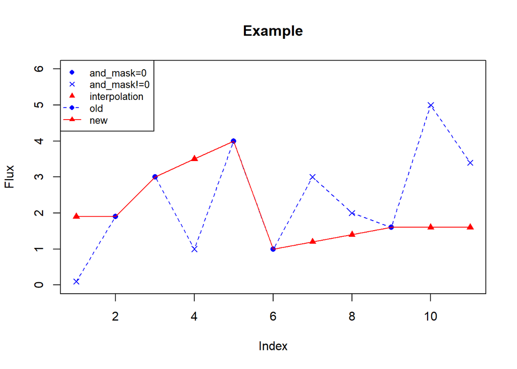

If one file has more than half and_mask!=0, I choose not to use linear interpolation and just let it go.

### Scale the data

I choose the method: subtract their mean and divided by the difference between maximum and minimum. This works well in my algorithm.

## Spectrum Alignment Algorithm

### First try: Simple

I use the simplest method which is just scan all of the spectrum one by one, which is very slow and do something useless. I compare the euclidean distance and the correlation coefficient. I find second one is more reasonable and fast. So this is my first method which also have a good result.

```
for(d in 1:length(filename)){
  data=get(filename[d])
  #plot(data$loglam,data$flux,type='l')

  #If too many and_mask != 0
  if (sum(data$and_mask != 0) > 0.5* nrow(data)){
    distance[d]=100
    next
  }
  i = 1
  j = 1
  cor_data <- c()
  for(i in 1:(nrow(data)-nrow(cB58)+1)){
    cor_data[i]=abs(cor(data$flux[i:(i+nrow(cB58)-1)],cB58$FLUX)-1)
  }
  distance[d] = min(cor_data)
}
```

Difficulty - It is time consuming and will not be useful for more data sets.

### Second try: Standard(Weighted) Euclidean Distance

But I find this method doesn’t use the *ivar* in the algorithm, so I come up with the second method which use the function d to show distance:
$$d = \frac{1}{n}\sqrt{\sum_{i=1}^{n}\omega_{i}(X_i-Y_i)^2}$$
which $\omega_i=ivar_i$

```
distance <- c()
for(d in 1:length(filename)){
  data=get(filename[d])
  #plot(data$loglam,data$flux,type='l')

  #If too many and_mask != 0
  if (sum(data$and_mask != 0) > 0.5* nrow(data)){
    distance[d]=100
    next
  }
  wei_dis_data <- c()
  i = 1
  j = 1
  while(i <= (nrow(data)-nrow(cB58)+1)){
    s = 0
    for(j in i:(i+nrow(cB58)-1)){
      s = s + data$ivar[j]*((data$flux[j]-cB58$FLUX[j-i+1])^2)
    }
    wei_dis_data[i%/%10+1]=(1/nrow(cB58))*sqrt(s)
    i=i+10
  }
  distance[d] = min(wei_dis_data)
}
```

Difficulty - The calculate value is too big and it will useless when getting larger files and also it is consuming. The *ivar* has a bad use.

### Best: Drops Search

Actually, because the two methods before just scan every i which is very time consuming. I think what I need to do is to find the characteristic points which contain the most important information in *cB58*.

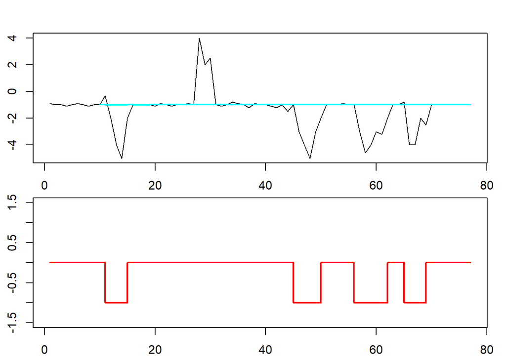

```r
PeakAlgorithm <- function(y,lag,thr) {
  meanstand <- c()
  stdstand <- c()
  return.list = list()
  ystand <- y[0:lag]
  peak <- rep(0,length(y))
  meanstand[lag] <- mean(y[0:lag])
  stdstand[lag] <- sd(y[0:lag])
  i = lag + 1
  while(i <= length(y)){
    if ( thr*stdstand[i-1] > abs(y[i]-meanstand[i-1])) {
      peak[i] = 0
      ystand[i] = y[i]
    }
    else {
      if (y[i] > log(thr)*meanstand[i-1]) {
        peak[i] = 0;
      } else {
        peak[i] = -1;
      }
      ystand[i] = ystand[i-1]
    }
    meanstand[i] = mean(ystand[(i-lag):i])
    stdstand[i] = sd(ystand[(i-lag):i])
    i=i+1
  }
  return.list$peak=peak
  return.list$meanstand=meanstand
  return.list$stdstand=stdstand
  return(return.list)
}
lag = 10
thr = 6
y <- c(0.9,1,1,1.1,1,0.9,1,1.1,1,1,0.3,2,4,5,2,1,1,1,1,1.1,0.9,1,1.1,1,1,0.9,
       1,-4,-2,-2.5,1,1.1,1,0.8,0.9,1,1.2,0.9,1,1,1.1,1.2,1,1.5,1,3,4,5,3,2,1,1,1,0.9,1,1,3,
       4.6,4,3,3.2,2,1,1,0.8,4,4,2,2.5,1,1,1,1,1,1,1,1)
y=-y
result <- PeakAlgorithm(y,lag,thr)
par(mfrow = c(2,1),oma = c(2,2,0,0) + 0.1,mar = c(0,0,2,1) + 0.2)
plot(1:length(y),y,type="l",ylab="",xlab="")
lines(1:length(y),result$meanstand,type="l",col="cyan",lwd=2)
plot(result$peak,type="S",col="red",ylab="",xlab="",ylim=c(-1.5,1.5),lwd=2)
```

I notice that the *cB58* has characteristic that they have some important drops or troughs. So my algorithm leave out the crest and mark the drops.

Then I analyze the *cB58*:

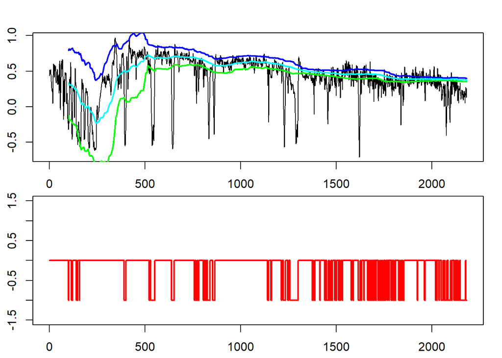

```r
cB58 <- readFrameFromFITS("cB58_Lyman_break.fit")
y = cB58$FLUX-mean(cB58$FLUX)/(max(cB58$FLUX)-min(cB58$FLUX))
lag       <- 100
thr       <- 2
result <- PeakAlgorithm(y,lag,thr)
par(mfrow = c(2,1),oma = c(2,2,0,0) + 0.1,mar = c(0,0,2,1) + 0.2)
plot(1:length(y),y,type="l",ylab="",xlab="")
lines(1:length(y),result$meanstand,type="l",col="cyan",lwd=2)
lines(1:length(y),result$meanstand+thr*result$stdstand,type="l",col="blue",lwd=2)
lines(1:length(y),result$meanstand-thr*result$stdstand,type="l",col="green",lwd=2)
plot(result$peak,type="S",col="red",ylab="",xlab="",ylim=c(-1.5,1.5),lwd=2)
```

Then use these drops to align with the 100 data sets and get top three:

Top:

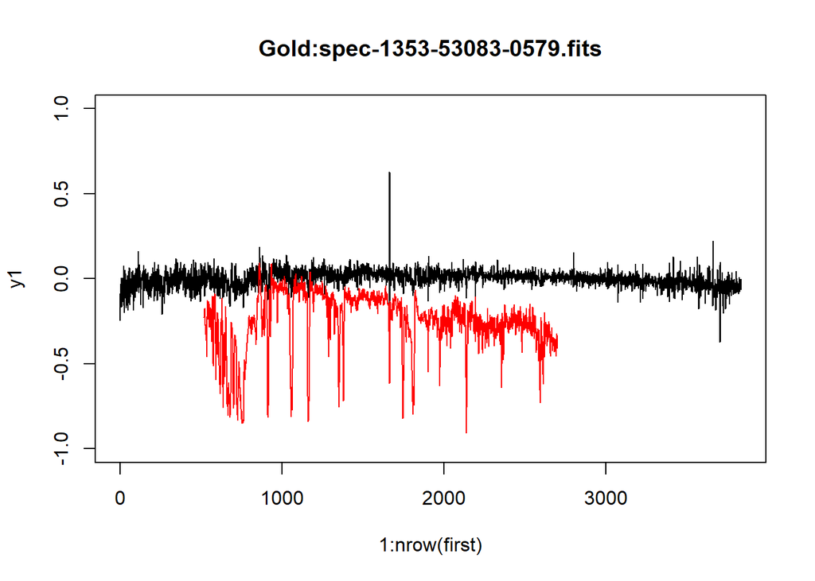

```r
result<-read.csv("hw2.csv")
fn <- c('first','second','third')
fileload <- c()
for(i in 1:3){
  fileload[i] <- paste("data/",result$spectrum[i],sep = "")
  assign(fn[i], readFrameFromFITS(fileload[i]))
}
 y1=(first$flux-mean(first$flux))/(max(first$flux)-min(first$flux))
 y2=(cB58$FLUX-mean(cB58$FLUX))/(max(cB58$FLUX)-min(cB58$FLUX) )
plot(x=1:nrow(first),y=y1,type = "l", main = paste("Gold",result$spectrum[1],sep = ":"), ylim =c(-1,1))
lines(x=result$i[1]:(result$i[1]+nrow(cB58)-1),y=y2-0.25,col="red")
```

Second:

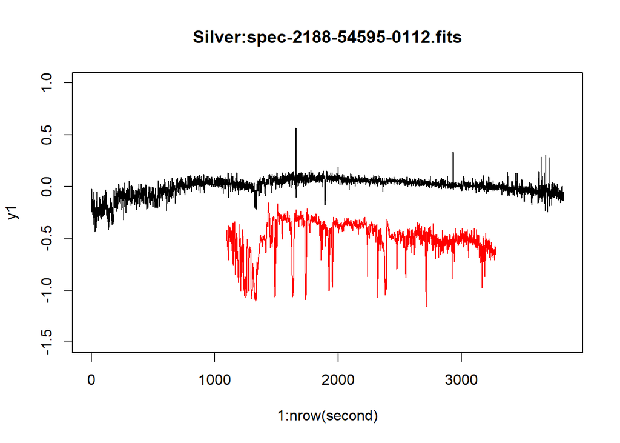

```r
y1=(second$flux-mean(second$flux))/(max(second$flux)-min(second$flux))
y2=(cB58$FLUX-mean(cB58$FLUX))/(max(cB58$FLUX)-min(cB58$FLUX))
plot(x=1:nrow(second),y=y1,type = "l", main = paste("Silver",result$spectrum[2],sep = ":"),ylim = c(-1.5,1))
lines(x=result$i[2]:(result$i[2]+nrow(cB58)-1),y=y2-0.5,col="red")
```

Third:

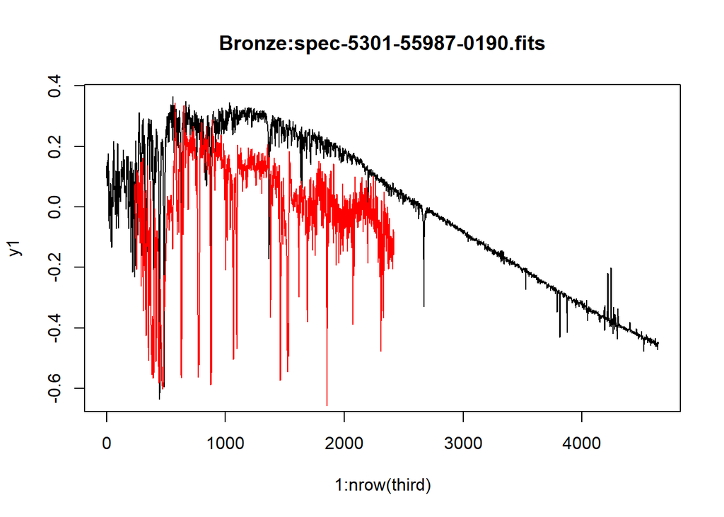

```r
y1=(third$flux-mean(third$flux))/(max(third$flux)-min(third$flux))
y2=(cB58$FLUX-mean(cB58$FLUX))/(max(cB58$FLUX)-min(cB58$FLUX))
plot(x=1:nrow(third),y=y1,type = "l", main = paste("Bronze",result$spectrum[3],sep = ":"))
lines(x=result$i[3]:(result$i[3]+nrow(cB58)-1),y=y2,col="red")
```

Difficulty - The scale is not good which make the shape of graph is different from the beginning. Actually they look same before the scale. Do not know how to use *ivar*.